# Assumption Validation

### A. Equality of task scenarios

Two different data analysis scenarios were used in the study. The “axis” scenario involved solving scheduling questions for a project manager. The “longmire” scenario involved solving scheduling questions for a conference events manager. The order of presentation of the scenarios (and therefore whether they were delivered with the linear or triangular model graph) were counterbalanced and randomly assigned. It is assumed that the scenarios are of equal difficulty.

**1. Linear model response TIMES for the axis and longmire scenarios should not be significantly different.**

[figure not shown]

```
participantData$lm_scenarios: axis
     nbr.val     nbr.null       nbr.na          min          max        range          sum       median         mean      SE.mean
 154.0000000    0.0000000    0.0000000    3.9200000   23.0600000   19.1400000 1325.6200000    8.1600000    8.6079221    0.2086524
CI.mean.0.95          var      std.dev     coef.var
   0.4122117    6.7045185    2.5893085    0.3008053
--------------------------------------------------------------------------------------------------------
participantData$lm_scenarios: longmire
     nbr.val     nbr.null       nbr.na          min          max        range          sum       median         mean      SE.mean
 184.0000000    0.0000000    0.0000000    4.6300000   22.0400000   17.4100000 1767.3100000    9.2700000    9.6049457    0.1747360
CI.mean.0.95          var      std.dev     coef.var
   0.3447561    5.6180087    2.3702339    0.2467722

    Welch Two Sample t-test

data:  w.lm.axis$LM_T_M and w.lm.longmire$LM_T_M
t = -3.6634, df = 313.81, p-value = 0.000292
alternative hypothesis: true difference in means is not equal to 0
95 percent confidence interval:
 -1.5325033 -0.4615439
sample estimates:
mean of x mean of y
 8.607922  9.604946

[1] 0.203
```

Mean response times for the linear model task were 8.61 minutes in the axis scenario and 9.60 minutes in the longmire scenario, significantly different t(313) = -3.66, p < 0.01 though representing a very small effect (r = 0.20).  
**It seems assumption #1 is violated… but how is this possible when the means are so close, the SD are comparable?.** ***

**2. Linear model response SCORES for the axis and longmire scenarios should not be significantly different.**

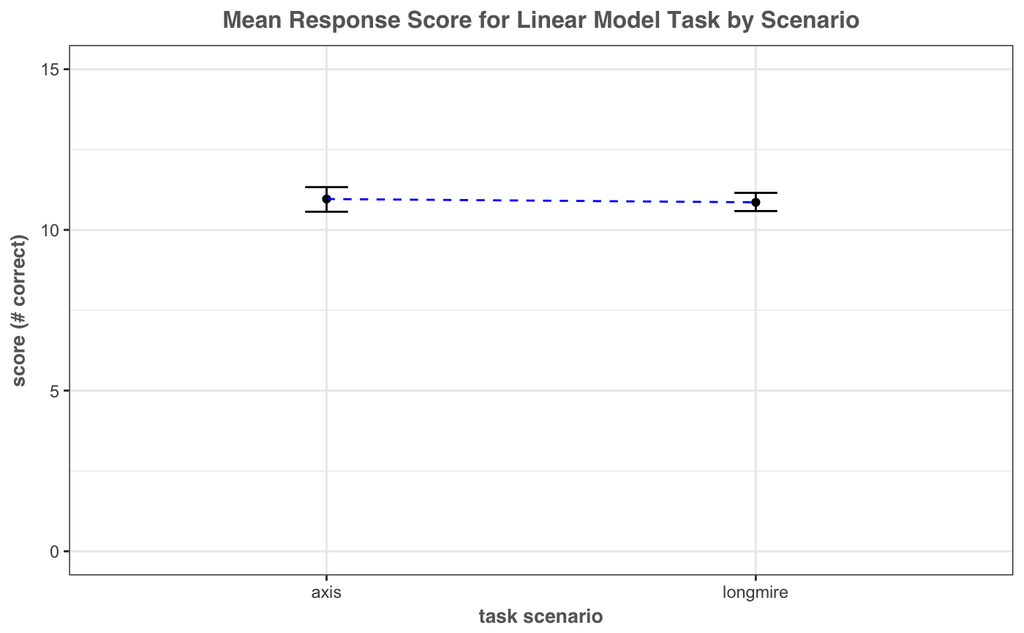

```
participantData$lm_scenarios: axis
     nbr.val     nbr.null       nbr.na          min          max        range          sum       median         mean      SE.mean
 154.0000000    0.0000000    0.0000000    2.0000000   15.0000000   13.0000000 1688.0000000   11.0000000   10.9610390    0.1925713
CI.mean.0.95          var      std.dev     coef.var
   0.3804420    5.7108904    2.3897469    0.2180219
--------------------------------------------------------------------------------------------------------
participantData$lm_scenarios: longmire
     nbr.val     nbr.null       nbr.na          min          max        range          sum       median         mean      SE.mean
 184.0000000    0.0000000    0.0000000    5.0000000   14.0000000    9.0000000 1998.0000000   11.0000000   10.8586957    0.1472733
CI.mean.0.95          var      std.dev     coef.var
   0.2905719    3.9908529    1.9977119    0.1839735

    Welch Two Sample t-test

data:  w.lm.axis$linear_score and w.lm.longmire$linear_score
t = 0.42215, df = 298.84, p-value = 0.6732
alternative hypothesis: true difference in means is not equal to 0
95 percent confidence interval:
 -0.3747462  0.5794328
sample estimates:
mean of x mean of y
 10.96104  10.85870

[1] 0.018
```

Mean response scores for the linear model task were 10.96 in the axis scenario and 10.86 in the longmire scenario, a nonsignificant difference, t(298) = 0.42, p = 0.67. **Therefore, assumption #2 is confirmed.**

**3. Triangular model response TIMES for the axis and longmire scenarios should not be significantly different.**

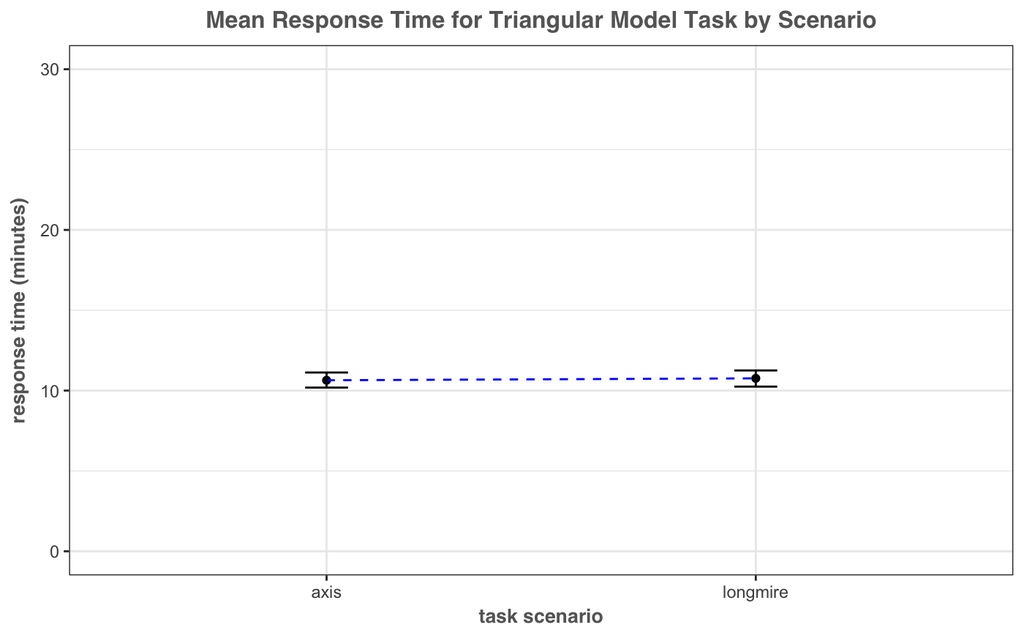

```
participantData$tm_scenarios: axis
     nbr.val     nbr.null       nbr.na          min          max        range          sum       median         mean      SE.mean
 184.0000000    0.0000000    0.0000000    3.9900000   26.8200000   22.8300000 1958.3000000   10.0050000   10.6429348    0.2479935
CI.mean.0.95          var      std.dev     coef.var
   0.4892941   11.3161400    3.3639471    0.3160733
--------------------------------------------------------------------------------------------------------
participantData$tm_scenarios: longmire
     nbr.val     nbr.null       nbr.na          min          max        range          sum       median         mean      SE.mean
 154.0000000    0.0000000    0.0000000    2.3700000   21.1800000   18.8100000 1657.3900000   10.4100000   10.7622727    0.2591974
CI.mean.0.95          var      std.dev     coef.var
   0.5120679   10.3462281    3.2165553    0.2988732

    Welch Two Sample t-test

data:  w.lm.axis$TM_T_M and w.lm.longmire$TM_T_M
t = 0.33267, df = 330.07, p-value = 0.7396
alternative hypothesis: true difference in means is not equal to 0
95 percent confidence interval:
 -0.5863388  0.8250147
sample estimates:
mean of x mean of y
 10.76227  10.64293

[1] 0.018
```

Mean response times for the triangular model task were 10.64 for the axis scenario and 10.76 for the longmire scenario, a nonsignificant difference, t(330) = 0.33, p = 0.73 with an extrememly small effect (r = 0.02).  
**Therefore, assumption #3 is confirmed.** ***

**4. Triangular model response SCORES for the axis and longmire scenarios should not be significantly different.**

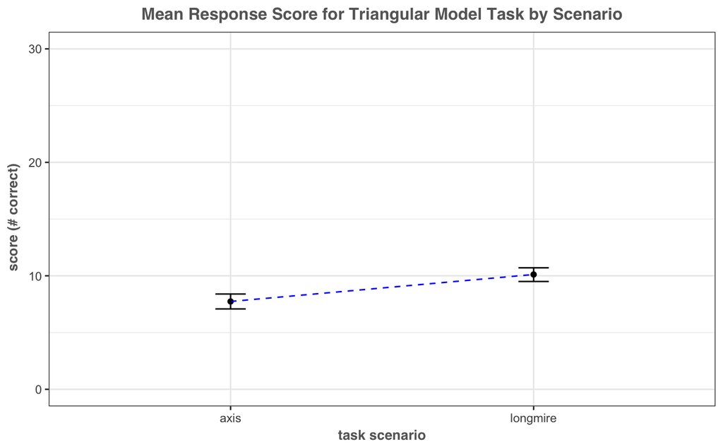

```
participantData$tm_scenarios: axis
     nbr.val     nbr.null       nbr.na          min          max        range          sum       median         mean      SE.mean
 184.0000000    5.0000000    0.0000000    0.0000000   15.0000000   15.0000000 1424.0000000    9.0000000    7.7391304    0.3376771
CI.mean.0.95          var      std.dev     coef.var
   0.6662410   20.9807555    4.5804755    0.5918592
--------------------------------------------------------------------------------------------------------
participantData$tm_scenarios: longmire
     nbr.val     nbr.null       nbr.na          min          max        range          sum       median         mean      SE.mean
 154.0000000    1.0000000    0.0000000    0.0000000   15.0000000   15.0000000 1558.0000000   11.0000000   10.1168831    0.3121548
CI.mean.0.95          var      std.dev     coef.var
   0.6166900   15.0058569    3.8737394    0.3828985

    Welch Two Sample t-test

data:  w.lm.axis$triangular_score and w.lm.longmire$triangular_score
t = 5.1707, df = 335.96, p-value = 4.015e-07
alternative hypothesis: true difference in means is not equal to 0
95 percent confidence interval:
 1.473195 3.282310
sample estimates:
mean of x mean of y
 10.11688   7.73913

[1] 0.272
```

Mean response scores for the triangular model task range were 7.74 in the axis scenario and 10.12 in the longmire scenario, a significant difference, t(336) = 5.17, p < 0.01, with a small effect (r = 0.27).  
**Therefore, assumption #4 is NOT confirmed.**